# CFRM 502, Winter 2020

# Instructor: Bahman Angoshtari

# Lecture 10

**Chapter 13:** forecasting ARIMA models, seasonal time series model (seasonal ARIMA)

```r
# Setting parameters of the Jupyter notebook
sc = .75
options(repr.plot.width=16*sc,
        repr.plot.height=7*sc,
        repr.plot.pointsize = 13, # Text height in pt
        repr.plot.bg        = 'white',
        repr.plot.antialias = 'gray',
        #nice medium-res DPI
        repr.plot.res       = 300,
        #jpeg quality bumped from default
        repr.plot.quality   = 90,
        #vector font family
        repr.plot.family    = 'serif')
# Vector font family. 'sans', 'serif', 'mono' or a specific one
```

$\newcommand\Fc{\mathscr{F}}$ $\newcommand{\eps}{\varepsilon}$ $\newcommand{\Var}{\operatorname{Var}}$ $\newcommand\Cov{\operatorname{Cov}}$ $\newcommand{\sig}{\sigma}$ $\newcommand{\al}{\alpha}$ $\newcommand{\Del}{\Delta}$ $\newcommand{\gam}{\gamma}$ $\newcommand{\tht}{\theta}$ $\newcommand{\Tht}{\Theta}$ $\newcommand\ph{\varphi}$ $\newcommand\rb{\bar{r}}$ $\newcommand{\Xb}{\bar{X}}$ $\newcommand{\Yb}{\bar{Y}}$ $\newcommand\Eb{\mathbb{E}}$ $\newcommand\Pb{\mathbb{P}}$ $\newcommand\Qb{\mathbb{Q}}$ $\newcommand\Rb{\mathbb{R}}$ $\newcommand\Zb{\mathbb{Z}}$ $\newcommand\Nb{\mathbb{N}}$ $\newcommand\Av{\textbf{A}}$ $\newcommand\Fv{\textbf{F}}$ $\newcommand\Gv{\textbf{G}}$ $\newcommand\Hv{\textbf{H}}$ $\newcommand\Kv{\textbf{K}}$ $\newcommand\Iv{\textbf{I}}$ $\newcommand\Pv{\textbf{P}}$ $\newcommand\Sv{\textbf{S}}$ $\newcommand\Xv{\textbf{X}}$ $\newcommand\Yv{\textbf{Y}}$ $\newcommand\Zv{\textbf{Z}}$ $\newcommand\av{\mathbf{a}}$ $\newcommand\xv{\mathbf{x}}$ $\newcommand\yv{\mathbf{y}}$ $\newcommand\zv{\mathbf{z}}$ $\newcommand\Cv{\mathbf{C}}$ $\newcommand\mv{\mathbf{m}}$ $\newcommand\nv{\mathbf{n}}$ $\newcommand\pv{\mathbf{p}}$ $\newcommand\sv{\mathbf{s}}$ $\newcommand\wv{\mathbf{w}}$ $\newcommand\Wv{\textbf{W}}$ $\newcommand\betav{{\boldsymbol\beta}}$ $\newcommand\etav{{\boldsymbol\eta}}$ $\newcommand\epsv{{\boldsymbol\varepsilon}}$ $\newcommand\delv{{\boldsymbol\delta}}$ $\newcommand\Lamv{{\boldsymbol\Lambda}}$ $\newcommand\lamv{{\boldsymbol\lambda}}$ $\newcommand\muv{{\boldsymbol\mu}}$ $\newcommand\piv{{\boldsymbol\pi}}$ $\newcommand\Pbh{\widehat{\Pb}}$ $\newcommand\phh{\widehat{\varphi}}$ $\newcommand\thth{\widehat{\theta}}$ $\newcommand\Ebh{\widehat{\Eb}}$ $\newcommand\Qh{\widehat{Q}}$ $\newcommand\Ih{\widehat{I}}$ $\newcommand\pih{\widehat{\pi}}$ $\newcommand\rh{\widehat{r}}$ $\newcommand\Pih{\widehat{\Pi}}$ $\newcommand\Wh{\widehat{W}}$ $\newcommand\Fh{\widehat{F}}$ $\newcommand\Yh{\widehat{Y}}$ $\newcommand\Yvh{\widehat{\Yv}}$ $\newcommand\Ah{\widehat{\Ac}}$ $\newcommand\uh{\widehat{u}}$ $\newcommand\vh{\widehat{v}}$ $\newcommand\fh{\widehat{f}}$ $\newcommand\hh{\widehat{h}}$ $\newcommand\Bh{\widehat{B}}$ $\newcommand\rhoh{\widehat{\rho}}$ $\newcommand\nuh{\widehat{\nu}}$ $\newcommand\varphih{\widehat{\varphi}}$ $\newcommand\alh{\widehat{\al}}$ $\newcommand\thetah{\widehat{\theta}}$ $\newcommand\betah{\widehat{\beta}}$ $\newcommand\betavh{\widehat{\boldsymbol\beta}}$ $\newcommand\kaph{\widehat{\kappa}}$ $\newcommand\sigh{\widehat{\sigma}}$ $\newcommand\epsh{\widehat{\eps}}$ $\newcommand\epsvh{\widehat{\epsv}}$ $\newcommand\epst{\widetilde{\eps}}$ $\newcommand\muh{\widehat{\mu}}$ $\newcommand\dd{\mathrm{d}}$ $\newcommand\ee{\mathrm{e}}$

# 0. Overview of the lecture

- In this lecture, we first learn how to predict future values of a time series using a fitted ARIMA(p,d,q) model
- We show, in detail, how to calculate the point estimates and their variance for simple AR(1) and MA(1) models. The calculations for general ARIMA models follow similar arguments.
- We then discuss an extension of ARIMA models for time series that are **seasonal**, meaning their values change according to a periodic pattern.

# 1. Forecasting ARIMA models

- Given observations $r_1,\dots, r_t$, what is the best estimate of $r_{t+h}$?
- We define the the $h$**-step-ahead forecast at time** $t$ by

\begin{align*} \rh_t(h) := \Eb(r_{t+h}|r_{t}, r_{t-1},\ldots) \end{align*}

- $t$ is the **forecast origin**
- $h$ is the **forecast horizon**
- The associated **forecast error** is

\begin{align*} e_t(h) := r_{t+h}-\rh_t(h) \end{align*}

- We are also interested in the variance of the forecast error $\Var\big(e_t(h)\big)$
- Once we find $\rh_t(h)$ and $\Var\big(e_t(h)\big)$, a 95% confidence interval for $r_{t+h}$ given by

\begin{align*} [\rh_t(h)-1.96\,\sqrt{\Var\big(e_t(h)\big)}, \rh_t(h)+1.96\,\sqrt{\Var\big(e_t(h)\big)}] \end{align*}

- Here, we have assumed that $\rh_t(h)$ is normally distributed
- These confidence intervals are usually called **"prediction intervals"**

## 1.1. Forecasting in AR(1) model

- Let us find forecasts and their variances for the AR(1) model

\begin{align*} &r_t=\mu+\ph(r_{t-1}-\mu) + \eps_t,\\ &\eps_t \sim \text{weak WN}(0,\sig^2_\eps) \end{align*}

- Since $r_{t+1}=$ $\mu+\ph(r_t-$ $\mu) +$ $ \eps_{t+1}$, we have

\begin{align*} \rh_t(1) &= \Eb(r_{t+1}|r_{t}, r_{t-1},\ldots)\\ &= \Eb\big(\mu+\ph(r_t-\mu) + \eps_{t+1}\big|r_{t}, r_{t-1},\ldots\big)\\ &= \mu+\ph(r_t-\mu) + \Eb\big(\eps_{t+1}\big|r_{t}, r_{t-1},\ldots\big)\\ &= \mu+\ph(r_t-\mu) \end{align*}

- Since we don't know the actual values of the parameters $\mu$ and $\ph$, we replace with their estimated values to obtain the **conditional forecast**

\begin{align*} \rh_t(1) = \muh+\phh(r_t-\muh). \end{align*}

- Note that we are not being rigorous here, since the estimates $\muh$ and $\phh$ are random variables and we are ignoring their uncertainty. It can be shown however, that if the sample size is large enough, the conditional forecasts are close to the correct value of the expectation $\Eb(r_{t+1}|r_{t}, r_{t-1},\ldots)$.
- It is possibility to consider parameter uncertainty in forecasting by taking a Bayesian approach such as forecasting with Markov Chain Monte Carlo (MCMC). This direction is outside the scope of this course.
- Next, we consider the 2-step-ahead forecast

\begin{align*} \rh_t(2) &= \Eb(r_{t+2}|r_{t}, r_{t-1},\ldots)\\ &= \Eb\big(\mu+\ph(r_{t+1}-\mu) + \eps_{t+2}\big|r_{t}, r_{t-1},\ldots\big)\\ &= \mu + \ph \big(\Eb(r_{t+1}|r_{t}, r_{t-1},\ldots)-\mu\big) + \Eb\big(\eps_{t+2}\big|r_{t}, r_{t-1},\ldots\big)\\ &= \mu+\ph(\rh_t(1)-\mu) \end{align*}

- As before, we replace the parameters with their estimates to obtain

\begin{align*} \rh_t(2) = \muh+\phh(\rh_t(1)-\muh) = \muh+\phh^2 (r_t-\muh). \end{align*}

- To get the second equation, we use the 1-step-ahead forecast equation

\begin{align*} \rh_t(1) = \muh+\phh(r_t-\muh)\Longrightarrow \rh_t(1)- \muh = \phh(r_t-\muh) \end{align*}

- In general, we have $\rh_t(h) =$ $ \muh +$ $ \phh^h(r_t-\muh)$
- As the forecast horizon $h\to\infty$, we have $\rh_t(h)= \muh + \phh^h(r_t-\muh) \to \muh$, assuming the AR(1) process is stationary so $|\ph|<1$.
- In other words, for a stationary AR(1) process, the forecast value far into the future is the estimated mean.
- This property is called the **"mean-reversion"** of AR(1) models
- A common way to quantify speed of mean-reversion is to use **"half-life"**
- Half-life is the minimum number of steps ahead $h$ needed for the following equation to hold:

\begin{align*} |\rh_t(h)-\muh|\le 0.5 |r_t-\muh| \end{align*}

- For an AR(1) model, one can show that

\begin{align*} \text{half-life} = \frac{\log(0.5)}{\log|\phh|} \end{align*}

- For example, if $\phh=-0.5$, then the half-life is 1, and if $\phh=0.9$, then the half-life is 6.58
- Q: How reliable are the n-step-ahead forecasts?
- To answer this question, we need to calculate forecast errors and their variances
- The error of the 1-step ahead forecasts $\rh_t(1) = \muh+\phh(r_t-\muh)$ is

\begin{align*} e_t(1) &:= r_{t+1} - \rh_t(1)\\\\ &= \mu + \ph(r_t-\mu) + \eps_{t+1} - \muh - \phh(r_t-\muh)\\\\ &= \mu - \muh + (\ph-\phh)r_t - (\ph\mu-\phh\muh) + \eps_{t+1} \end{align*}

- To simplify this equation, we consider a scenario with a large sample $r_1, \dots, r_{t}$
- In such case, we expect $\mu\approx\muh$ and $\ph\approx\phh$
- Thus, we find the **"large-sample approximation"** of forecast errors to be

\begin{align*} e_t(1)\approx \eps_{t+1} \end{align*}

- Similarly, the large sample approximation of n-step ahead forecast errors can be obtained (show this!)

\begin{align*} e_t(h) := r_{t+1} - \rh_t(h) = \dots = \eps_{t+h} + \ph \eps_{t+h-1} + \ph^2 \eps_{t+h-2} + \dots + \ph^{h-1} \eps_{t+1} \end{align*}

- We can then find the large-sample approximation of the variance of forecasts errors.
- For 1-step ahead forecasts, we have

\begin{align*} \Var(e_t(1))\approx \Var(\eps_{t+1}) = \sig_\eps^2 \end{align*}

- In general:

\begin{align*} \Var(e_t(h)) &\approx \Var\left(\eps_{t+h} + \ph \eps_{t+h-1} + \ph^2 \eps_{t+h-2} + \dots + \ph^{h-1} \eps_{t+1}\right)\\\\ &= (1+\ph^2+\ph^4 + \dots + \ph^{2(h-1)})\sig_\eps^2 \\\\ &= \frac{1-\ph^{2h}}{1-\ph^2}\sig^2_\eps \end{align*}

- Note that as $h$ gets larger, $\Var\big(e_t(h)\big)$ increases, and that we have:

\begin{align*} \lim_{n\to\infty} \Var\big(e_t(h)\big) = \frac{\sig^2_\eps}{1-\ph^2} =\gam(0) \end{align*}

- Here, $\gam(0)$ is the stationary variance of the AR(1) process.
- This is a general result for stationary ARMA models. As the forecast horizon gets larger, the large-sample variance of forecast errors tends to the stationary variance of ARMA process.
- With forecasts and estimates of their variance at hand, the **prediction intervals** are given by

\begin{align*} \left[\rh_t(h)-1.96\,\sqrt{\frac{1-\phh^{2h}}{1-\phh^2}\sigh^2_\eps},\,\, \rh_t(h)+1.96\,\sqrt{\frac{1-\phh^{2h}}{1-\phh^2}\sigh^2_\eps}\right] \end{align*}

## 1.2. Forecasting in MA(1) model

- As another example, let us calculate forecasts and their variances for the MA(1) model

\begin{align*} &r_t = \mu + \eps_t + \theta\,\eps_{t-1},\\ &\eps_t \sim \text{weak WN}(0,\sig^2_\eps) \end{align*}

- Since $r_{t+1} = $ $\mu + \eps_{t+1} +$ $ \theta\,\eps_{t}$, we have

\begin{align*} &\Eb(r_{t+1}|r_{t}, r_{t-1},\ldots)\\\\ &= \Eb\big(\mu + \eps_{t+1} + \theta\,\eps_{t}\big|r_{t}, r_{t-1},\ldots\big)\\\\ &= \mu + \Eb\big(\eps_{t+1}\big|r_{t}, r_{t-1},\ldots\big) + \tht\, \Eb\big(\eps_t\big|r_{t}, r_{t-1},\ldots\big) \end{align*}

- As before, $\Eb\big(\eps_{t+1}\big|r_{t}, r_{t-1},\ldots\big)=0$, since $r_{t}, r_{t-1},\ldots$ are defined by $\eps_{t}, \eps_{t-1},\ldots$, which are uncorrelated with $\eps_{t+1}$
- Note, however, that $\Eb\big(\eps_t\big|$ $r_{t}, r_{t-1},\ldots\big)$ $=\epsh_t$.
- This is correct for any ARIMA(p,q,d) model, actually. We just didn't need it for calculating AR(1) forecasts!
- We then obtain $\Eb(r_{t+1}|$ $r_{t}, r_{t-1},\ldots)$ $ = \mu + $ $\tht\, \epsh_t$
- By replacing the unknown parameters with their estimates, we obtain the conditional 1-step-ahead forecasts

\begin{align*} \rh_t(1) = \muh + \thth\, \epsh_t \end{align*}

- The 2 step-ahead forecast is calculated as follows

\begin{align*} &\Eb(r_{t+2}|r_{t}, r_{t-1},\ldots)\\\\ &= \Eb\big(\mu + \eps_{t+2} + \theta\,\eps_{t+1}\big|r_{t}, r_{t-1},\ldots\big)\\\\ &= \mu + \Eb\big(\eps_{t+2}\big|r_{t}, r_{t-1},\ldots\big) + \tht\, \Eb\big(\eps_{t+1}\big|r_{t}, r_{t-1},\ldots\big)\\\\ &= \mu \end{align*}

- So, $\rh_t$ $(2) $ $= \muh$.
- Similarly $\rh_t(h) = \muh$ for $h\ge 2$ in the $MA(1)$ model.
- Next, let us calculate the variances of the forecast errors.
- The 1 step-ahead forecast error is

\begin{align*} e_t(1) &:= r_{t+1} - \rh_t(1)\\\\ &= \mu + \eps_{t+1} + \theta\,\eps_{t} - \muh - \thth\, \epsh_t \\\\ &= \mu - \muh + \theta\,\eps_{t} - \thth\, \epsh_t + \eps_{t+1} \end{align*}

- The large sample approximation of the forecast errors is obtained by substituting $\mu$, $\tht$, and $\eps_t$ with their estimates $\muh$, $\thth$, and $\epsh_t$, respectively. This yields

\begin{align*} e_t(1) \approx \eps_{t+1} \end{align*}

- So, the large sample variance of 1-step-ahead forecast error is $\Var(\eps_{t+1})=\sig_\eps^2$.
- For $h\ge2$, the h step-ahead forecast error is

\begin{align*} e_t(h) &:= r_{t+h} - \rh_t(h)\\\\ &= \mu + \eps_{t+h} + \theta\,\eps_{t+h-1} - \muh \\\\ &= \mu - \muh + \eps_{t+h} + \theta\,\eps_{t+h-1} \end{align*}

- So, the large sample approximation of the $h$ step-ahead forecast error is $e_t(h)\approx \eps_{t+h} + \theta\,\eps_{t+h-1}$, which yields the large sample variance of h-step-ahead forecast error $\Var(\eps_{t+h} + \theta\,\eps_{t+h-1})= (1+\tht^2)\sig_\eps^2$.
- Forecasts for AR(p), MA(q), ARMA(p,q), and ARIMA(p,d,q) processes follows similar arguments. Read section 12.12 of the textbook for more details

## 1.3. Forecasting ARIMA models with R

- Let us illustrate by forecasting inflation rates example from the previous lecture

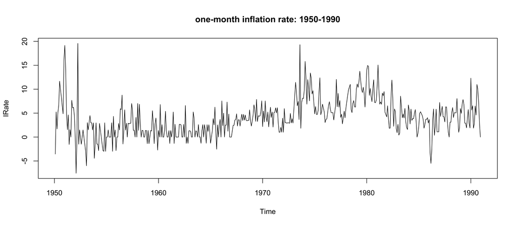

```r
data(Mishkin, package = "Ecdat")
IRate = as.ts(Mishkin[,1], start=1950, frequency=12)
ts.plot(IRate, main="one-month inflation rate: 1950-1990")
```

- In the previous lecture, we fitted the ARIMA(1,1,1) model:

  $\Delta I_t = 0.2383\,\Delta I_{t-1} + \eps_t -0.8772\, \eps_{t-1}$, where $(\eps_t)$ is weak WN$(0, \sig_\eps^2=8.587)$

```r
library("forecast")
FitARIMA_BIC = auto.arima(as.numeric(IRate), max.p=20, max.q = 20, max.d=2, ic="bic")
print(FitARIMA_BIC)
```

```
Series: as.numeric(IRate)
ARIMA(1,1,1)

Coefficients:
         ar1      ma1
      0.2383  -0.8772
s.e.  0.0550   0.0269

sigma^2 estimated as 8.587:  log likelihood=-1221.62
AIC=2449.25   AICc=2449.29   BIC=2461.83
```

- We can use the `predict()` function to obtain forecasts and their errors

```r
pr = predict(FitARIMA_BIC,6)
names(pr)
```

1. 'pred'

2. 'se'

```r
print(pr$pred)
```

```
Time Series:
Start = 492
End = 497
Frequency = 1
[1] 3.706101 4.589298 4.799773 4.849930 4.861884 4.864732
```

```r
print(pr$se)
```

```
Time Series:
Start = 492
End = 497
Frequency = 1
[1] 2.930391 3.115623 3.175183 3.215216 3.250915 3.285350
```

- With the standard error of the forecasts, it is easy to obtain prediction intervals

```r
LPI = pr$pred - 1.96 * pr$se
UPI = pr$pred + 1.96 * pr$se
print(LPI)
print(UPI)
```

```
Time Series:
Start = 492
End = 497
Frequency = 1
[1] -2.037466 -1.517322 -1.423586 -1.451893 -1.509911 -1.574553
Time Series:
Start = 492
End = 497
Frequency = 1
[1]  9.449667 10.695919 11.023131 11.151754 11.233678 11.304018
```

- Time series forecast and prediction intervals are usually added to the time series plot

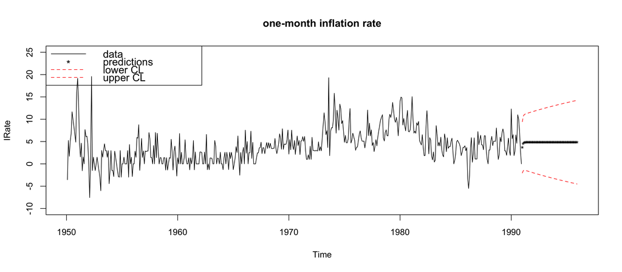

```r
pr = predict(FitARIMA_BIC,60)
ts.plot(IRate, ylim=c(-10,25), xlim=c(1950,1996), type='l',
        main="one-month inflation rate")
lines(ts(pr$pred, star=1991, frequency=12), type='p', lty=1, pch='*')
lines(ts(pr$pred+1.96*pr$se, star=1991, frequency=12), type='l', lty=2,col=2)
lines(ts(pr$pred-1.96*pr$se, , star=1991, frequency=12), type='l', lty=2,col=2)
legend("topleft",c("data","predictions","lower CL","upper CL"),cex=1.2,
       box.lty=1,pch=c(NA,"*",NA,NA),lty=c(1,NA,2,2), col=c(1,1,2,2))
```

# 2. Seasonal time series models

- Seasonal time series exhibit certain **cyclical** or **periodic** behavior
- Earnings data is usually seasonal. Seasonality is also present in the price of environment-related financial assets, such as weather derivatives or energy futures

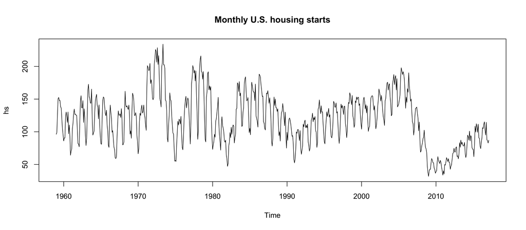

```r
hs = ts(read.table("m-hs.txt", header=TRUE)[,2],
        start=1959, frequency=12)
ts.plot(hs, main="Monthly U.S. housing starts")
```

- In the plot below, note that by taking the log, we handle both the exponential trend and the non-constant variance of the earning time series.

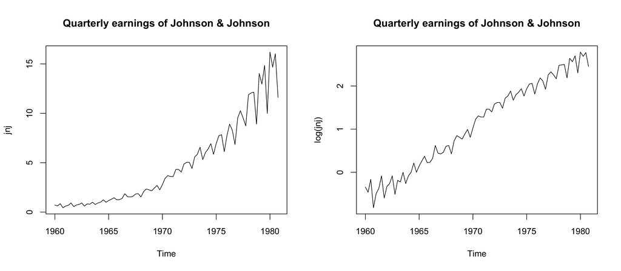

```r
par(mfrow=c(1,2))
jnj = ts(read.table("q-earn-jnj.txt")[,1], start=1960, frequency=4)
ts.plot(jnj, main="Quarterly earnings of Johnson & Johnson")
ts.plot(log(jnj), main="Quarterly earnings of Johnson & Johnson")
```

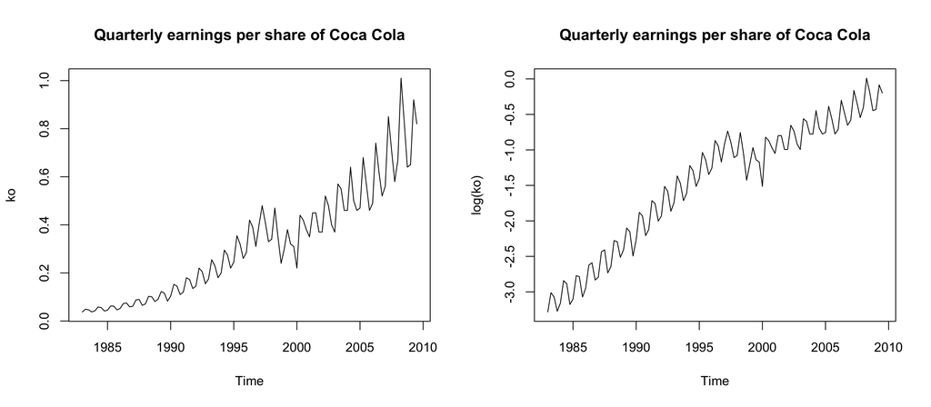

```r
par(mfrow=c(1,2))
ko = ts(read.table("q-earn-ko.txt", header=TRUE)[,3],
        start=1983, frequency=4)
ts.plot(ko, main="Quarterly earnings per share of Coca Cola")
ts.plot(log(ko), main="Quarterly earnings per share of Coca Cola")
```

- There are two approaches to seasonal time series

  (1) **Seasonal adjustment:** the affect of seasonality is not important (or is of secondary importance). The times series is transformed into a non-seasonal time series. The adjusted time series is then analyzed. Most published economic data (such as GDP growth rate and unemployment rate) are seasonally adjusted.

  (2) Seasonality is as important as other characteristics of the data and must be modeled. This approach is specifically relevant if the main purpose of the model is forecasting.
- Here, we focus on the second approach.
- Consider the log quarterly earnings of J&J, let us denote it by $\{r_t\}$
- The sample ACF shows high autocorrelation (is the time series stationary?)

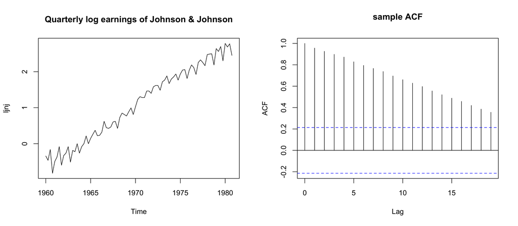

```r
par(mfrow=c(1,2))
ljnj = log(jnj)
ts.plot(ljnj, main="Quarterly log earnings of Johnson & Johnson")
acf(as.numeric(ljnj), main="sample ACF");
```

- To remove non stationarity, we take the difference of the series, $\Del r_t = r_t - r_{t-1}$
- Note the significant autocorrelation at lags 4, 8, 12, ...
- This is the characteristic behavior of the ACF of seasonal time series

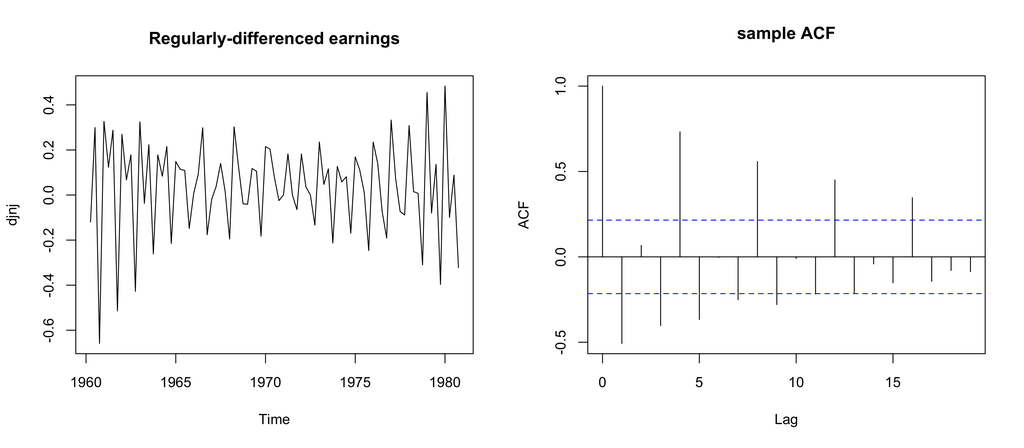

```r
par(mfrow=c(1,2))
djnj = diff(ljnj)
ts.plot(djnj, main="Regularly-differenced earnings")
acf(as.numeric(djnj), main="sample ACF");
```

- To remove seasonality of periodicity 4, we can take the **seasonal difference** $\Del_4 r_t = r_t - r_{t-4}$
- Do not confuse the seasonal difference $\Del_4 r_t$ with (regular) 4th order difference $\Del^4=\Del\bigg(\Del\Big(\Del\big(\Del r_t)\big)\Big)\bigg)$
- In R, `diff(r, lag=4)`, or `diff(r, 4)` yields the seasonal difference $\Del_4$.
- `diff(r, differences=4)` yields the 4th order regular difference $\Del^4$
- Taking seasonal difference removes the autocorrelation at lag 4, 8, ...

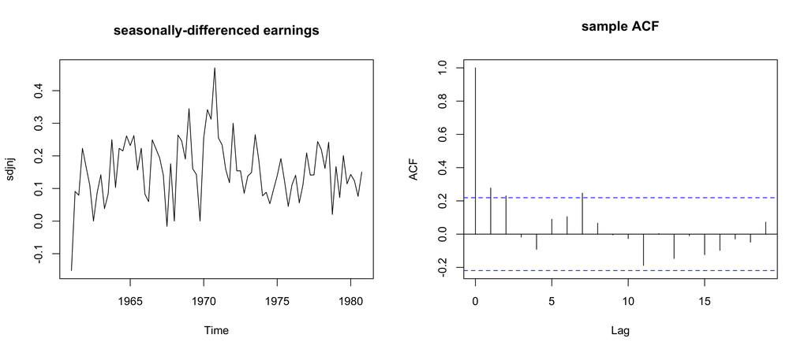

```r
par(mfrow=c(1,2))
sdjnj = diff(ljnj, 4)
ts.plot(sdjnj, main="seasonally-differenced earnings")
acf(as.numeric(sdjnj), main="sample ACF");
```

- To get an even better time series, we can combine regular and seasonal differencing

\begin{align*} \Del_4(\Del r_t) = \Del_4(r_t-r_{t-1}) = r_t - r_{t-1} - (r_{t-4}-r_{t-5}) = r_t-r_{t-1}-r_{t-4}+r_{t-5}. \end{align*}

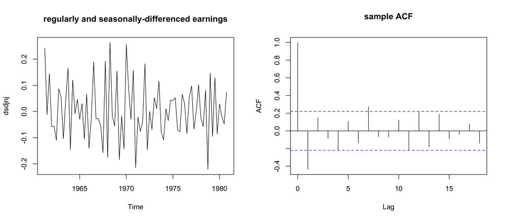

```r
par(mfrow=c(1,2))
dsdjnj = diff(sdjnj)
ts.plot(dsdjnj, main="regularly and seasonally-differenced earnings")
acf(as.numeric(dsdjnj), main="sample ACF");
```

- It is easy to show that the order of seasonal and regular differencing does not matter, that is, $\Del_4(\Del r_t) = \Del(\Del_4 r_t)$ (check this).

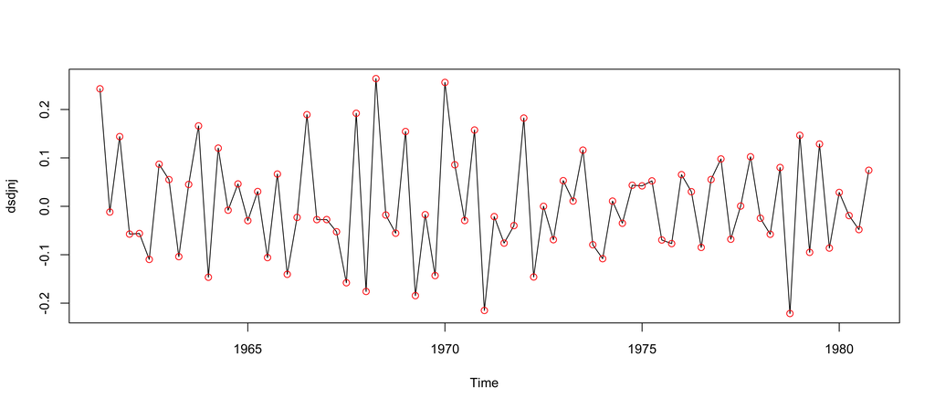

```r
dsdjnj2 = diff(djnj, 4)
ts.plot(dsdjnj)
lines(dsdjnj2, type="p", col='red')
```

- Let us quickly check the other two seasonal time series to see if seasonal differencing helps with removing seasonality.

```r
seasonalACF = function(ts, slag, name){
    par(mfrow=c(2,2),mar=c(2,3,4,4))
    acf(as.numeric(ts), main=paste("sample ACF of ", name))
    acf(as.numeric(diff(ts)), main="first difference")
    acf(as.numeric(diff(ts,slag)), main="seasonal difference")
    acf(as.numeric(diff(diff(ts),slag)), main="regular+seasonal differene")
}
```

- The Coca Cola earning per shares (EPS) series is seasonally adjusted with $\Del_4$

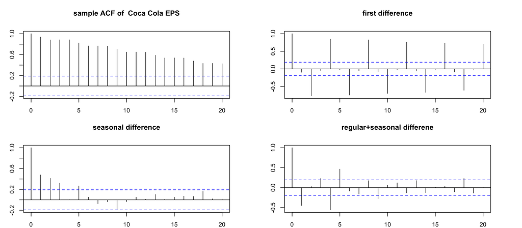

```r
seasonalACF(log(ko), 4, "Coca Cola EPS")
```

- It looks like the housing starts series is not seasonally adjusted with $\Del_4$. Why?

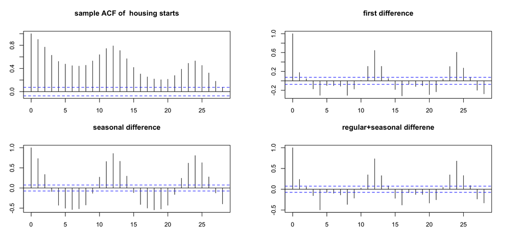

```r
seasonalACF(hs, 4, "housing starts")
```

- We forget that the housing starts series was monthly data!
- So, the periodicity is 12 and not 4. we should apply $\Del_{12}$, which removes the periodicity.
- Note that the periodicity can be inferred from the first difference ACF.

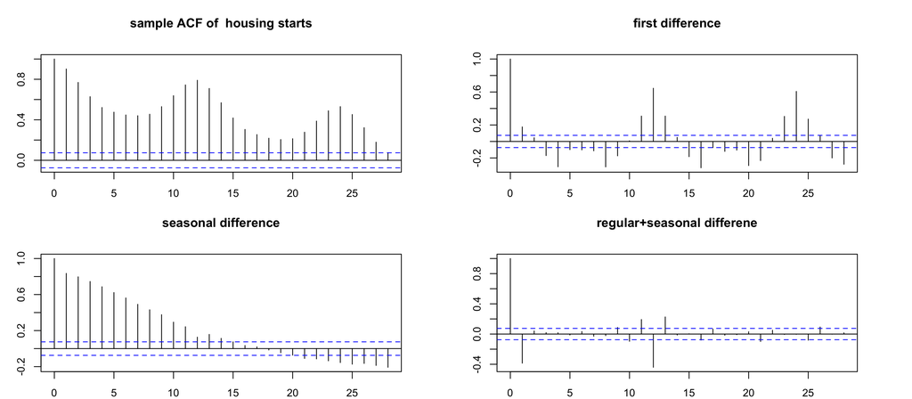

```r
seasonalACF(hs, 12, "housing starts")
```

## 2.2. The airline model

- Many seasonal time series can be adjusted by using the seasonal and regular difference
- To introduce the seasonal time series models, it is best to introduce the **"lag operator"**
- Let us define the lag operator $B\, r_t := r_{t-1}$
- Furthermore, let us define $B^k r_t $ $:= \underbrace{B B \dots B}_{k\text{ times}}\, r_t $ $= r_{t-k}$
- Using the lag operator, the ARMA(1,1) model

\begin{align*} r_t - \mu - \phi_1 (r_{t-1}-\mu) = \eps_t + \tht_1 \eps_{t-1} \end{align*}

- can be written as follows

\begin{align*} r_t - \mu - \phi_1 B (r_t - \mu) = \eps_t + \tht_1 B \eps_t \end{align*}

- or, more succinctly,

\begin{align*} (1-\phi_1 B)(r_t - \mu) = (1+\tht_1 B)\eps_t \end{align*}

- Although, we only write $r_t$ and $\eps_t$ in this equation, the lagged values of $r_{t-1}$ and $\eps_{t-1}$ are also present because of $B$.
- Similarly, the ARMA(p,q) model can be written as follows (convince yourself)

\begin{align*} (1-\sum_{k=1}^p \phi_k B^k)(r_t - \mu) = (1+\sum_{\ell=1}^q\tht_\ell B^\ell)\eps_t \end{align*}

- The regular difference is $\Del r_t =$ $ r_t - r_{t-1} =$ $ (1-B) r_t$
- The lag-$s$ seasonal difference is $\Del_s r_t $ $= r_t - r_{t-s} =$ $ (1-B^s) r_t$
- So, the seasonal and regular difference can be written as follows

\begin{align*} \Del \Del_s r_t = (1 - B)(1-B^s)\,r_t \end{align*}

- The **airline model** is a simple model for seasonal times series

\begin{align*} \begin{cases} (1-B)(1-B^s) r_t = (1+\tht B)(1+\Tht B^s)\eps_t,\\ \eps_t \sim \text{weak WN}(0,\sig_\eps^2). \end{cases} \end{align*}

- This model has three parameters, $\tht$, $\Tht$, and $\sig_\eps^2$
- $s$ is the periodicity of the seasonal time series.
- Let us define $x_t = $ $(1-B)$ $(1-B^s)$ $r_t$
- Then, the airline model becomes

\begin{align*} \begin{cases} x_t = (1+\tht B + \Tht B^s + \tht\Tht B^{s+1})\eps_t,\\ \eps_t \sim \text{weak WN}(0,\sig_\eps^2). \end{cases} \end{align*}

- Thus, we may think of the airline model for $\{r_t\}$ as a MA($s+1$) model for $x_t$ with the following additional conditions: $\tht_1=\tht$, $\tht_s = \Tht$, $\tht_{s+1}=\tht\Tht$, and $\tht_2=\dots=\Tht_{s-1}=0$.
- Estimation and diagnostic of the airline model is similar to an MA model. Let us illustrate this next.
- We may use the `arima` function to fit the airport model by using
  - `order=(0,1,1)` to state the regular first difference and regular MA(1)
  - `seasonal=list(order=c(0,1,1), period = s)` to state the seasonal difference at lag $s$ and the seasonal MA(1)

```r
jnj_airline = arima(as.numeric(ljnj), order=c(0,1,1),
                    seasonal=list(order=c(0,1,1), period=4))
jnj_airline
```

```
Call:
arima(x = as.numeric(ljnj), order = c(0, 1, 1), seasonal = list(order = c(0,
    1, 1), period = 4))

Coefficients:
          ma1     sma1
      -0.6809  -0.3146
s.e.   0.0982   0.1070

sigma^2 estimated as 0.007931:  log likelihood = 78.38,  aic = -150.75
```

- The fitted airline model is:

\begin{align*} \begin{cases} (1-B)(1-B^s) r_t = (1-0.6809\, B)(1-0.3146 B^s)\eps_t,\\ \eps_t \sim \text{weak WN}(0,0.007931). \end{cases} \end{align*}

- The diagnostic is the same as an ARIMA model.
- The output below indicates that the model is adequate.

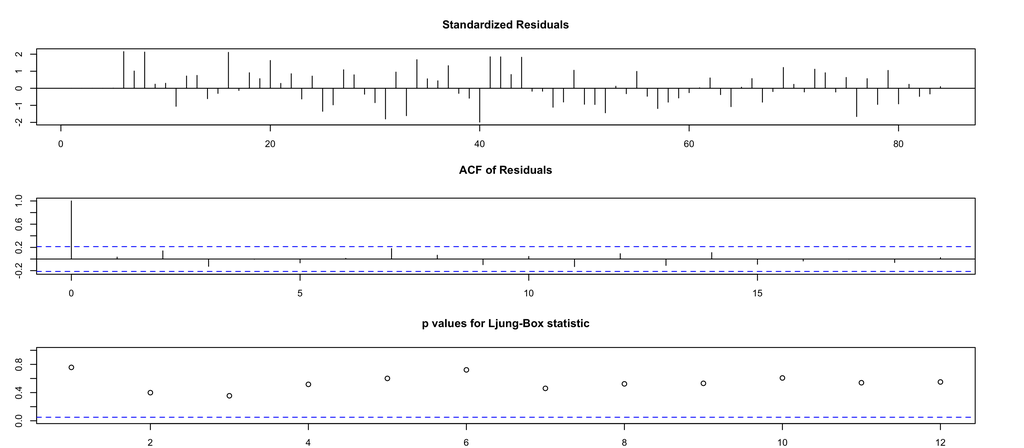

```r
par(mar=c(2,3,4,4))
tsdiag(jnj_airline,gof=12)
```

- Next, we check the residuals for constant volatility and normality.

```r
tsdiag_vol = function(model, lag, fitdf, span=0.5){
    par(mfrow=c(1,2));par(mar=c(3,3,3,3))
    plot(resid(model)**2, type="l", col=1,
         main = expression(residual^2))
    smoother = loess((resid(model)**2) ~ seq(1,length(resid(model))),
                     span=span)
    lines(seq(1,length(resid(model))),fitted(smoother),col=2)
    acf((resid(model)**2), main=expression("sample ACF of "~ residual^2))
    Box.test(resid(model)**2, lag = lag, type = "Ljung-Box", fitdf = fitdf)
}
tsdiag_norm = function(model){
    qqnorm(resid(model), datax = FALSE,
       xlab = "normal quantile",
       ylab = "sample quantile of residuals",
       main = "normal probability plot for residuals")
    qqline(resid(model), datax=FALSE, col = 2)
    shapiro.test(resid(model))
}
```

- Ljung-Box test indicates that the volatility is constant

```
	Box-Ljung test

data:  resid(model)^2
X-squared = 13.029, df = 10, p-value = 0.222
```

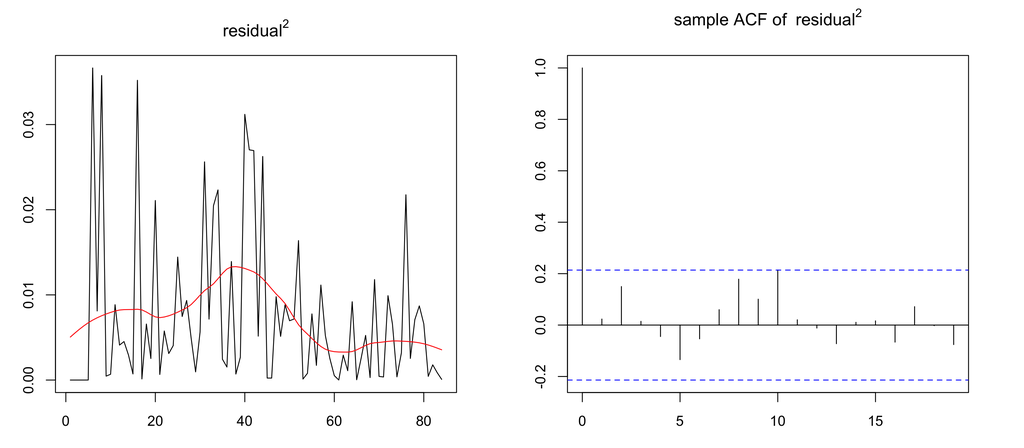

```r
tsdiag_vol(jnj_airline, lag=12, fitdf=2)
```

- The residuals are normal.

```
	Shapiro-Wilk normality test

data:  resid(model)
W = 0.98583, p-value = 0.489
```

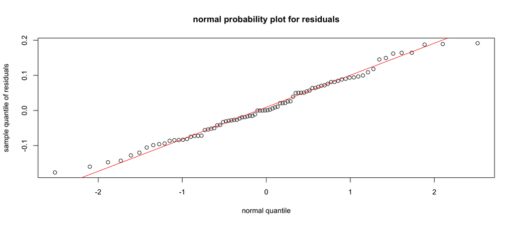

```r
tsdiag_norm(jnj_airline)
```

- To predict using the airline model, we can use the `predict()` function as in the case of ARIMA models

```r
pred_jnj = predict(jnj_airline,8)
pred_jnj
```

**$pred**

A Time Series:

1. 2.9053427791774

2. 2.8238912536671

3. 2.91214764629056

4. 2.58108540321762

5. 3.03645011327038

6. 2.95499858776009

7. 3.04325498038355

8. 2.71219273731061

**$se**

A Time Series:

1. 0.0890541389689504

2. 0.0934789944097751

3. 0.0977036597278956

4. 0.101753072939278

5. 0.135487709034138

6. 0.143705610657945

7. 0.151478334324835

8. 0.158871234039018

- We can then plot the observed and predicted values of the log earning and their confidence interval

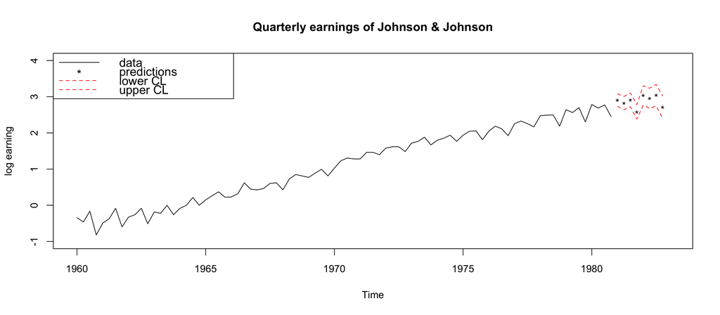

```r
ts.plot(ljnj, ylim=c(-1,4), xlim=c(1960,1983), type='l',
        main="Quarterly earnings of Johnson & Johnson", ylab="log earning")
lines(ts(pred_jnj$pred, start=1981, frequency=4), type='p', lty=1, pch='*')
lines(ts(pred_jnj$pred+1.96*pred_jnj$se, start=1981, frequency=4), type='l', lty=2,col=2)
lines(ts(pred_jnj$pred-1.96*pred_jnj$se, start=1981, frequency=4), type='l', lty=2,col=2)
legend("topleft",c("data","predictions","lower CL","upper CL"),cex=1.2,
       box.lty=1,pch=c(NA,"*",NA,NA),lty=c(1,NA,2,2), col=c(1,1,2,2))
```

## 2.3. Multiplicative seasonal models

- The airline model is a special case of the **multiplicative seasonal ARIMA** model

\begin{align*} \underbrace{(1-\sum_{k=1}^p \phi_k B_k)}_{\text{regular AR(p)}}\,\underbrace{(1-\sum_{i=1}^P \Phi_i B^{i\times s})}_\text{seasonal AR(P)} \underbrace{(\Del^d\Del_s^D r_t - \mu)}_\text{regular-seasonal diff.} = \underbrace{(1+\sum_{\ell=1}^q \tht_\ell B^\ell)}_\text{regular MA(q)}\underbrace{(1+\sum_{j=1}^Q\Tht_j B^{j\times s})}_\text{seasonal MA(Q)}\eps_t, \end{align*}

- Here, $\{\eps_t\}$ is weak WN$(0,\sig_\eps^2)$, $s$ is the periodicity, $d$ is the regular integration order, and $D$ is the seasonal integration order.
- This model is denoted by ARIMA$\{(p,d,q)\times(P,D,Q)_s\}$
- So, the airline model is ARIMA$\{(0,1,1)\times(0,1,1)_s\}$
- `auto.arima()` function automatically check for seasonality. If seasonality exists (according to a statistical test), then it fits a seasonal ARIMA model.
- For the Johnson & Johnson example, `auto.arima()` suggest a ARIMA$\{(1,0,0)\times(0,1,0)_4\}$ model:

\begin{align*} \begin{cases} (1-0.3155\,B)\Del_4 (r_t - 0.0386\, t) = \eps_t,\\ \eps_t \sim \text{weak WN}(0,0.008344). \end{cases} \end{align*}

```r
jnj_SARIMA = auto.arima(ljnj, ic="bic",
                        max.p=20, max.q = 20, max.d=3,
                        max.P=20, max.Q = 20, max.D=3)
jnj_SARIMA
```

```
Series: ljnj
ARIMA(1,0,0)(0,1,0)[4] with drift

Coefficients:
         ar1   drift
      0.3155  0.0386
s.e.  0.1137  0.0037

sigma^2 estimated as 0.008344:  log likelihood=78.89
AIC=-151.78   AICc=-151.47   BIC=-144.64
```

- Note that the output specifies a **"drift"** instead of an **"intercept"**
- The model is adequate.

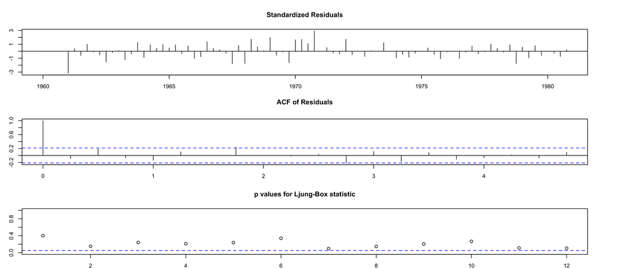

```r
par(mar=c(2,3,4,4))
tsdiag(jnj_SARIMA, gof=12)
```